# Technical Report: Full House Modeling for rankings of historical figures separated by biological sex

Daniel J. Eck and Shen Yan and Adrian Burgos Jr. and Elisha Cohen

In this technical report we go through the steps that we took to rank historical figures via an era-neutral version of the Historical Popularity Index (HPI) in [Yu et al (2016)](https://www.nature.com/articles/sdata201575) obtained via Full House Modeling. In this report we perform our analyses on females and males separately, and the results are then combined together.

This technical report is reproducible by anyone who has the package and our data sets. Long code chunks that create plots will be suppressed. Code for these plots is available in the accompanying .Rmd file. This report will cover the following topics:

# List of Topics

- Data Preparation: Data preprocessing steps and software
- Full House Modeling: Definition of Full House Modeling
  - Full House Modeling for Females: Implementation, diagnostics, and results of Full House Modeling for females
  - Full House Modeling for Males: Implementation, diagnostics, and results of Full House Modeling for males
  - Combined Analysis: Combination of results from the female and male analyses

# Data Preparation

Population data collection is through 05/17/2022. The Pantheon data used is the [2020 Person Dataset version 2.0](https://pantheon.world/data/datasets). We load in the following software packages:

```r
library(tidyverse)
library(knitr)
library(kableExtra)
library(readxl)
library(splines)
library(Hmisc)
library(parallel)
library(orderstats)
library(Pareto)
library(doParallel)
library(fullhouse)

# get number of cores
nCores = detectCores() - 2
nCores
```

```
## [1] 8
```

We load in the Pantheon data set

```r
persons2020 = read_csv("person_2020_update.csv")
```

We remove duplicates of bios with a common name and birth year.

```r
persons2020 =
  persons2020 %>% distinct(name, birthyear, .keep_all = TRUE)
```

We change Donald Trump’s 2020 HPI value of 94.9 to his 2022 HPI value of 78.13. Our aim is to study the most impactful people in history. We do not think it proper to conduct our analyses with Donald Trump’s popularity in 2020 when he had fallen 679 spots in two years and is still living at the time of this analysis. While HPI is a proxy measure of impact through popularity, the intention of HPI is to correct recency biases. We felt it best to ignore an active historical figure whose current popularity might not be reflective of their historic popularity.

```r
persons2020 = persons2020 %>%
  mutate(hpi = ifelse(name == "Donald Trump", 78.13, hpi)) %>%
  arrange(desc(hpi))
```

Here we define eras to constitute a relatively narrow range of years. The most recent year in our analysis in 1980. The eras will be defined by the centuries, and we will only consider eras that have at least 50 people in the Pantheon data set. Our first era begins in 800 BC, the second begins in 700 BC, and so on.

We will define Jesus’s and other Christian figures’ birth year to be 0 AD. This is done to separate memorable Christian figures from memorable Roman figures into different peer groups. We moved Jesus instead of Julius Ceasar and other Roman figures because [Jesus’s birth year is not exactly known](https://en.wikipedia.org/wiki/Jesus).

```r
## consider generations with increasing year ranges
## include country of birth
generations = c(-8:19 * 100)
persons2020_small = persons2020 %>%
  dplyr::select(name, gender, birthyear, bplace_country, hpi) %>%
  filter(birthyear >= -800, birthyear <= 1980)
persons2020_small$group =
  unlist(lapply(persons2020_small$birthyear,
    function(x) sum(x >= generations)))
persons2020_small = persons2020_small %>% filter(group > 0)
persons2020_small = persons2020_small %>%
  mutate(group = ifelse(name %in% c("Jesus", "Saint Peter", "Mary Magdalene",
                     "Andrew the Apostle", "James, son of Alphaeus"), 9, group))
```

[output not shown]

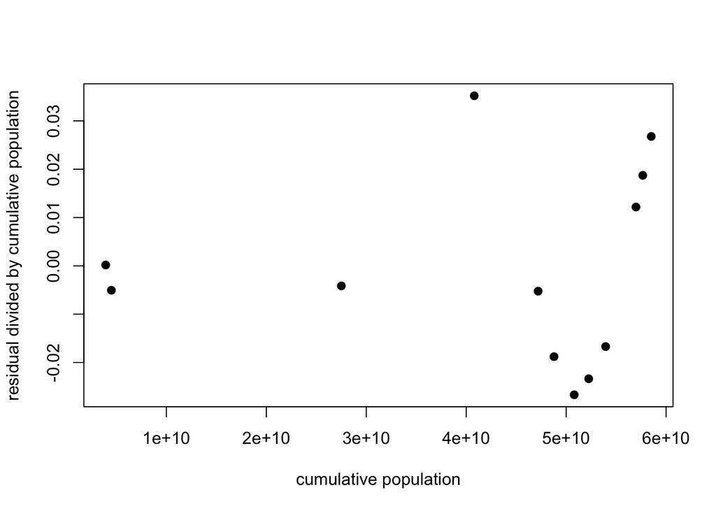

[output not shown]

```r
#### Edited up to Here: Need to decide how to construct historical eligible population
####  - Probably no females correction if analyzing males and females separately
####  - Also do a breakdown across males vs females and Europe/US vs non-Europe/US
####    - Possibly no Euro correction for the above 4 group breakdown

#head(persons2020_small)

tab = table(persons2020_small$bplace_country) %>% sort(., decreasing = TRUE)
#tab

## https://www.countries-ofthe-world.com/countries-of-europe.html
Europe = c("United Kingdom", "Germany", "France", "Italy", "Russia", "Spain",
           "Poland", "Sweden", "Turkey", "Austria", "Netherlands", "Ukraine",
           "Greece", "Belgium", "Czechia", "Denmark", "Hungary", "Switzerland",
           "Norway", "Romania", "Finland", "Ireland", "Croatia", "Cyprus",
           "Portugal", "Serbia", "Bulgaria", "Georgia", "Slovakia", "Estonia",
           "Bosnia and Herzegovina", "Latvia", "Belarus", "Lithuania",
           "Slovenia", "Azerbaijan", "Iceland", "Armenia", "Kazakhstan",
           "North Macedonia", "Montenegro", "Albania", "Moldova", "Luxembourg",
           "Malta", "Kosovo", "Monaco", "San Marino", "Andorra",
           "Liechtenstein", "Czech Republic", "Vatican City")

## Continental North America
North_America = c("United States", "Canada", "Mexico")
```

The estimated cumulative eligible population is displayed below.

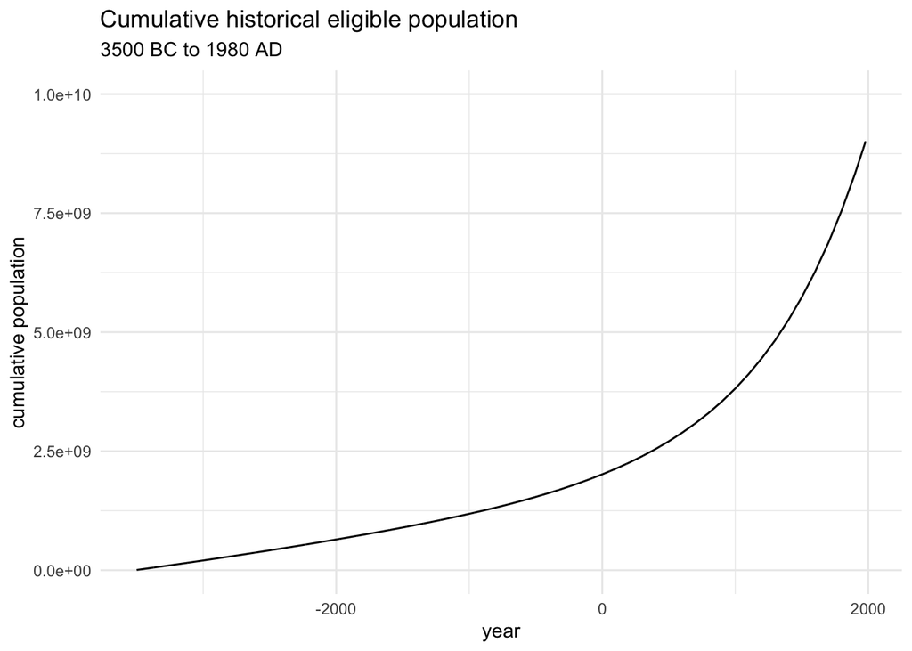

```r
ggplot(dat_HPI_eligible_FM) +
  aes(x = year, y = cumulative_population) +
  ylim(-1e6, 1e10) +
  geom_line() +
  theme_minimal() +
  labs( x = "year", y = "cumulative population",
        title ="Cumulative historical eligible population",
        subtitle = "3500 BC to 1980 AD")
```

We now split the Pantheon data set and historical eligible population data set into smaller chunks containing data for each biological sex and each separate era. We will consider biographies beginning in 100 BC dues to sparse biological entries for females prior to this date. Below are two important quantities:

1. **hpi_generations**: This list contains the name, birth year, and HPI value of individuals within the historical eras.
2. **Epop_generations**: This data set contains the the number of people that populate each era. This population is defined as the difference in the range of population tallies recorded for end points defining an era. The first era runs from 100 BC to 1 BC. The population of the era is the cumulative historical population at 1 BC minus the cumulative historical population at 100 BC.

```r
foo = split(persons2020_small, f = as.factor(persons2020_small$gender))

## bios for females and males
persons2020_small_F = foo$F
persons2020_small_M = foo$M
persons2020_small_F_8 = persons2020_small_F %>% filter(group >= 8)
persons2020_small_M_8 = persons2020_small_M %>% filter(group >= 8)
hpi_generations_F_8 = lapply(split(persons2020_small_F_8,
                               f = as.factor(persons2020_small_F_8$group)),
                         function(xx) xx %>% select(-group))
hpi_generations_M_8 = lapply(split(persons2020_small_M_8,
                                   f = as.factor(persons2020_small_M_8$group)),
                             function(xx) xx %>% select(-group))

## population tally for each generation
Epop_generations_8 = c(dat_HPI_eligible_FM %>%
                         filter(year >= - 100,
                                year %in% c(generations, 1980)) %>%
                       pull(cumulative_population) %>% diff())
cum_prop_population_8 = cumsum(Epop_generations_8) / sum(Epop_generations_8)
generations_8 = generations[generations >= - 100]
```

Below we display some information on each of the eras. We display the populations of an era, the cumulative proportion of the historical population through that era, and the number of Pantheon biographies in each era.

```r
gen_stats_F_8 = data.frame(
  gen_start = generations_8,
  gen_end = c(generations_8[-1] -1, 1980),
  gen_pop = Epop_generations_8,
  cum_prop_population = cum_prop_population_8,
  n = sapply(hpi_generations_F_8, nrow)
)
gen_stats_F_8
```

```
##    gen_start gen_end   gen_pop cum_prop_population     n
## 8       -100      -1 108274871          0.01524238    52
## 9          0      99 116724089          0.03167420    40
## 10       100     199 126291241          0.04945284    34
## 11       200     299 137144617          0.06875936    38
## 12       300     399 149478848          0.08980222    33
## 13       400     499 163519216          0.11282162    24
## 14       500     599 179526658          0.13809447    41
## 15       600     699 197803561          0.16594024    40
## 16       700     799 218700478          0.19672778    38
## 17       800     899 242623904          0.23088313    44
## 18       900     999 270030049          0.26889658    57
## 19      1000    1099 301379740          0.31132328    73
## 20      1100    1199 337175459          0.35878912   134
## 21      1200    1299 377979848          0.41199919   144
## 22      1300    1399 424421465          0.47174707   145
## 23      1400    1499 477200889          0.53892497   159
## 24      1500    1599 537097160          0.61453477   226
## 25      1600    1699 604974524          0.69969999   271
## 26      1700    1799 681789438          0.79567882   431
## 27      1800    1899 768597788          0.90387808  1710
## 28      1900    1980 682805839          1.00000000 10350
```

```r
gen_stats_M_8 = data.frame(
  gen_start = generations_8,
  gen_end = c(generations_8[-1] -1, 1980),
  gen_pop = Epop_generations_8,
  cum_prop_population = cum_prop_population_8,
  n = sapply(hpi_generations_M_8, nrow)
)
gen_stats_M_8
```

```
##    gen_start gen_end   gen_pop cum_prop_population     n
## 8       -100      -1 108274871          0.01524238   235
## 9          0      99 116724089          0.03167420   169
## 10       100     199 126291241          0.04945284   205
## 11       200     299 137144617          0.06875936   206
## 12       300     399 149478848          0.08980222   228
## 13       400     499 163519216          0.11282162   210
## 14       500     599 179526658          0.13809447   232
## 15       600     699 197803561          0.16594024   264
## 16       700     799 218700478          0.19672778   225
## 17       800     899 242623904          0.23088313   332
## 18       900     999 270030049          0.26889658   375
## 19      1000    1099 301379740          0.31132328   475
## 20      1100    1199 337175459          0.35878912   584
## 21      1200    1299 377979848          0.41199919   565
## 22      1300    1399 424421465          0.47174707   535
## 23      1400    1499 477200889          0.53892497   848
## 24      1500    1599 537097160          0.61453477  1152
## 25      1600    1699 604974524          0.69969999  1161
## 26      1700    1799 681789438          0.79567882  2705
## 27      1800    1899 768597788          0.90387808  9904
## 28      1900    1980 682805839          1.00000000 32654
```

Back to topics

# Full House Modeling

Full House Modeling uses an interpolated empirical CDF $\widetilde{F}_{Y_i}$ as an estimate of the true distribution function for the $Y$ data as in [Yan (2025)](https://projecteuclid.org/journals/annals-of-applied-statistics/volume-19/issue-2/Comparing-baseball-players-across-eras-via-novel-Full-House-Modeling/10.1214/24-AOAS1992.short). This estimator is constructed in the following manner: First, surrogate sample points %$\widetilde{Y}_{i,(1)}, \ldots, \widetilde{Y}_{i,(n_i+1)}$ as, $\widetilde{Y}_{i,(1)} =Y_{i,(1)}-Y^{*}_i$, $\widetilde{Y}_{i,(j)} =\left(Y_{i,(j)}+Y_{i,(j-1)}\right) / 2, j=2, \ldots, n_i$, and $\widetilde{Y}_{i,(n_i+1)} =Y_{i,(n_i)}+Y^{**}_i$. Here, $Y^*_i$ is the value to construct the lower bound and $Y^{**}_i$ is the value to construct the upper bound. Now let,
$$\begin{equation} \label{eq:empcdf}
\widetilde{F}_{Y_i}(t) =
\sum_{j=1}^{n_i}\left(\frac{j-1}{n_i} +
\frac{t-\widetilde{Y}_{i,(j)}}{n_i\left(\widetilde{Y}_{i,(j+1)}-\widetilde{Y}_{i,(j)}\right)}\right)
1\left(\widetilde{Y}_{i,(j)} \leq
t<\widetilde{Y}_{i,(j+1)}\right)+1\left(t \geq
\widetilde{Y}_{i,(n_i+1)}\right).
\end{equation}$$
Back to topics

## Full House Modeling for Females

We first compute $y^{\star\star}$ using the function in the package. First, the number of extreme observations $k$ is calculated following a similar approach to that outlined in Section 2.2.3 of [Yan (2025)](https://projecteuclid.org/journals/annals-of-applied-statistics/volume-19/issue-2/Comparing-baseball-players-across-eras-via-novel-Full-House-Modeling/10.1214/24-AOAS1992.short) and Section 5 of [Scholz (1995)](https://faculty.washington.edu/fscholz/Reports/extrap.pdf) which is implemented in the function in the package.

```r
system.time({
  kmat_F_8 = do.call(rbind, mclapply(seq_along(hpi_generations_F_8),
                                 FUN = function(j) {
                                   k_finder(x = hpi_generations_F_8[[j]] %>% pull(hpi))
                                 }, mc.cores = nCores))
})
```

```
##    user  system elapsed
##   4.774   0.413  84.632
```

The modeling of the $k$ tail probabilities also closely follows Section 2.2.3 of [Yan (2025)](https://projecteuclid.org/journals/annals-of-applied-statistics/volume-19/issue-2/Comparing-baseball-players-across-eras-via-novel-Full-House-Modeling/10.1214/24-AOAS1992.short). However, there are some notable differences. The main difference is that the simple modeling approach in Section 2.2.3 of [Yan (2025)](https://projecteuclid.org/journals/annals-of-applied-statistics/volume-19/issue-2/Comparing-baseball-players-across-eras-via-novel-Full-House-Modeling/10.1214/24-AOAS1992.short) does not work well for all eras that we consider. Namely, there is a problem with model fit in some circumstances and a value for $y^{\star\star}$ cannot be computed. We add local polynomial models (fit with in R) on the linear and logistic scale to the set of candidate models. Quadratic and cubic models were also considered.

The task of computing $y^{\star\star}$ is implemented in the function which is included in the package and called below. This function computes $y^{\star\star}$ in the following manner: we first calculate $k$ as above. THe upper bound $Y_i^{**}$ is estimated through a connection between $\widetilde{F}_{Y_i}(Y_{i,(n_i)})$ and the regression fit on $(h(p_{i,j,.5,n_i}), Y_{i,(j)})$, $j = n_i -k + 1,\ldots,n_i$ where $h$ is a selected model in the tail probabilities. We find $Y_i^{**}$ as the solution of the following optimization problem
$$\begin{equation}
\label{eq:optim}
Y_i^{**} = \text{argmin}_y\Big|h^{-1}(Y_{i,(n_i)}) -
\widetilde{F}_{Y_i}(Y_{i,(n_i)};y)\Big|,
\end{equation}$$
where $\widetilde{F}_{Y_i}(\cdot;y)$ is $\widetilde{F}_{Y_i}$ defined with $y$ replacing $Y_i^{**}$ in its construction.

In addition to $y^{\star\star}$, the function includes the tail probability model and data used to fit the model for each era.

```r
system.time({
  out_F_8 = mclapply(seq_along(hpi_generations_F_8),
                 FUN = function(j) {
                   compute_ystarstar(x = hpi_generations_F_8[[j]] %>% pull(hpi),
                                     k = kmat_F_8[j, 1])
                 },
                 mc.cores = nCores)
})
```

```
##    user  system elapsed
##   0.132   0.115   0.189
```

```r
## get ystarstar values
ystar_mat_F_8 = do.call(rbind, lapply(seq_along(hpi_generations_F_8),
                                  function(j) out_F_8[[j]]$ystar )
)
```

We now provide the line of best fit for the tail probabilities for each era. We can see adequate fit throughout.

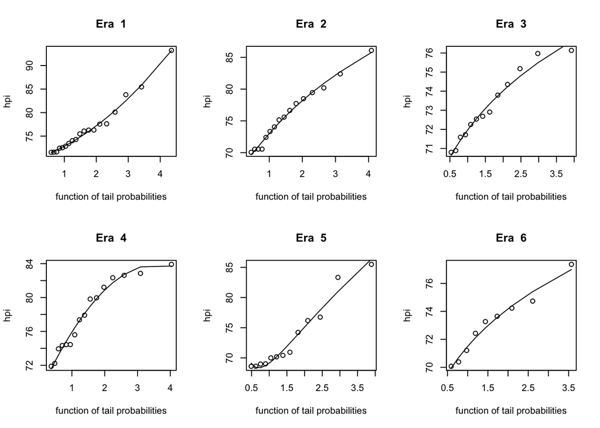

```r
par(mfrow = c(2,3))
for(j in 1:6){
  plot(out_F_8[[j]]$W, out_F_8[[j]]$Y, main = paste("Era ", j),
       xlab = "function of tail probabilities", ylab = "hpi")
  lines(out_F_8[[j]]$W, predict(out_F_8[[j]]$model))
}
```

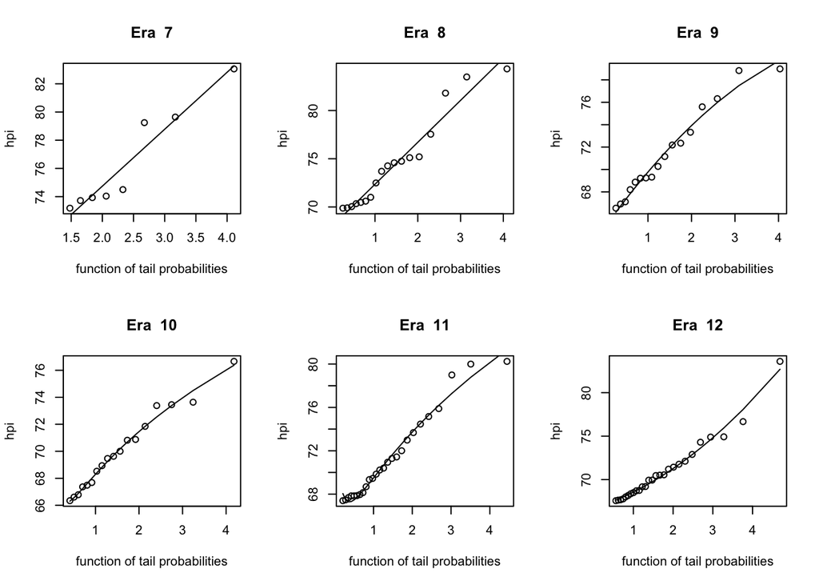

```r
par(mfrow = c(2,3))
for(j in 7:12){
  plot(out_F_8[[j]]$W, out_F_8[[j]]$Y, main = paste("Era ", j),
       xlab = "function of tail probabilities", ylab = "hpi")
  lines(out_F_8[[j]]$W, predict(out_F_8[[j]]$model))
}
```

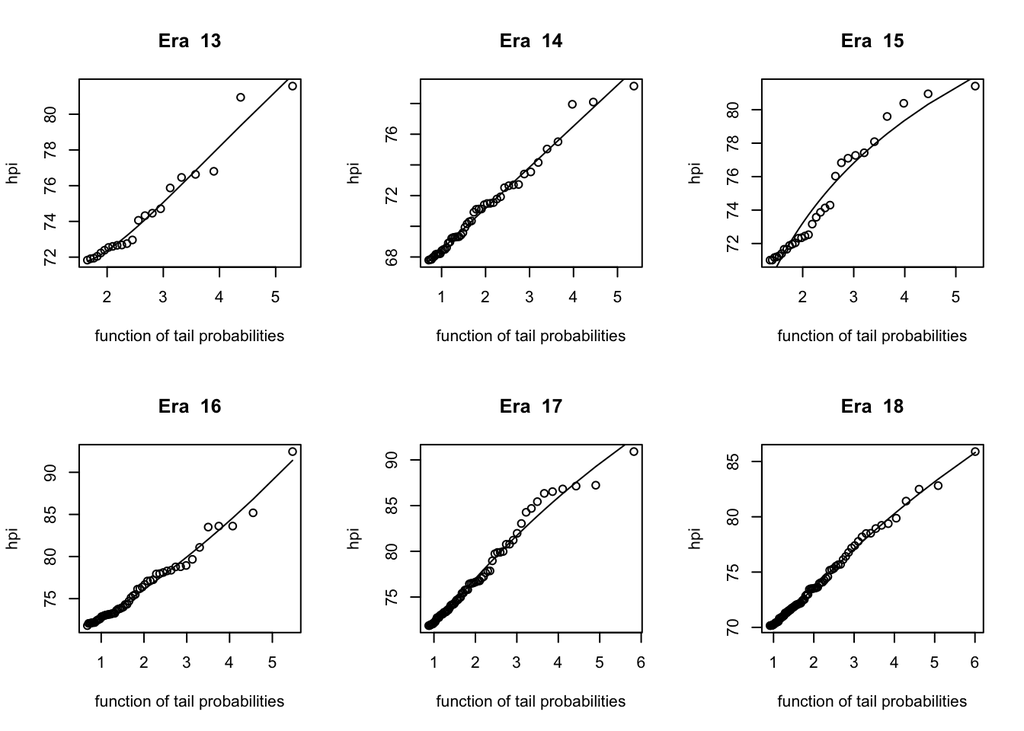

```r
par(mfrow = c(2,3))
for(j in 13:18){
  plot(out_F_8[[j]]$W, out_F_8[[j]]$Y, main = paste("Era ", j),
       xlab = "function of tail probabilities", ylab = "hpi")
  lines(out_F_8[[j]]$W, predict(out_F_8[[j]]$model))
}
```

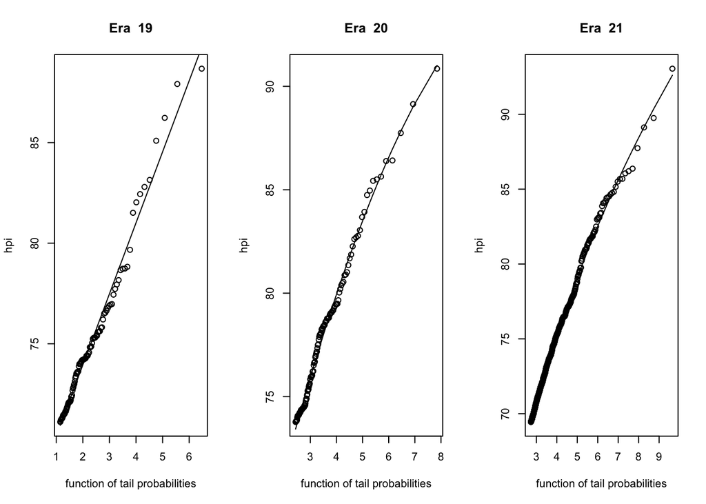

```r
par(mfrow = c(1,3))
for(j in 19:21){
  plot(out_F_8[[j]]$W, out_F_8[[j]]$Y, main = paste("Era ", j),
       xlab = "function of tail probabilities", ylab = "hpi")
  lines(out_F_8[[j]]$W, predict(out_F_8[[j]]$model))
}
```

We now compute latent talent estimates using Full House Modeling and the stored $y^{\star\star}$ values. This task is implemented in the function which is included in the package and called below. These estimates of latent talent are
$$F_{X_{i, (N_i - n_i +
j)}}^{-1}\left(F_{U_{i,(j)}}\left(\widetilde{F}_{Y_{i}}\left(Y_{i,(j)}
\right)\right)\right) \approx F_{X_{i, (N_i - n_i +
j)}}^{-1}\left(F_{U_{i,(j)}}\left(U_{i,(j)}\right)\right) = X_{i, (N_i -
n_i + j)},$$
where we suppose that $X_{i,j} \overset{iid}{\sim} \text{Pareto}(\alpha)$, $\alpha = 1.16$ (the value corresponding to the [Pareto principle](https://en.wikipedia.org/wiki/Pareto_principle)), $j = 1,\ldots,n_i$.

```r
## vs your peers
system.time({
  hpi_adjust_vs_peers_F_8 =
    mclapply(seq_along(hpi_generations_F_8), mc.cores = nCores, function(j){
      talent_computing_nonpara(ystar = as.numeric(ystar_mat_F_8[j, 1]),
                               y = hpi_generations_F_8[[j]]$hpi,
                               npop = Epop_generations_8[[j]])
      })
  })
```

```
##    user  system elapsed
##   1.588   0.185  49.120
```

```r
hpi_era_adjusted_F_8 = do.call(rbind, lapply(seq_along(hpi_adjust_vs_peers_F_8), function(j){
  foo = cbind(hpi_generations_F_8[[j]], hpi_adjust_vs_peers_F_8[j])
  colnames(foo)[ncol(foo)] = "talent"
  foo
})) %>%
  select(-gender) %>%
  arrange(desc(talent))
```

Here is the top 50 list of the most impactful females in history ranked by estimated latent talent obtained via Full House Modeling. In this analysis there are 21 distinct eras defined by centuries to designate peer groups. Females are modeled separately from males in this analysis.

```r
hpi_era_adjusted_F_8 %>% as.data.frame() %>% head(50)
```

```
##                            name birthyear bplace_country      hpi   talent
## 1                  Elizabeth II      1926 United Kingdom 93.04777 6.031743
## 2                   Marie Curie      1867         Poland 90.85337 6.007910
## 3            Mary II of England      1662 United Kingdom 85.89593 5.987234
## 4                   Joan of Arc      1412         France 92.46169 5.975767
## 5              Marie Antoinette      1755        Austria 88.67393 5.952432
## 6        Elizabeth I of England      1533 United Kingdom 90.90742 5.922610
## 7           Hildegard of Bingen      1098        Germany 83.59769 5.895167
## 8                 Maria Theresa      1717        Austria 87.91266 5.890564
## 9                Queen Victoria      1819 United Kingdom 89.14118 5.882746
## 10           Catherine of Siena      1347          Italy 81.41340 5.867702
## 11                 Olga of Kiev       890         Russia 76.65813 5.856987
## 12              Clare of Assisi      1193          Italy 81.57545 5.852205
## 13         Elizabeth of Hungary      1207       Slovakia 79.13546 5.839248
## 14                  Frida Kahlo      1907         Mexico 89.75289 5.834699
```

[output cut: 36 more lines]

Back to topics

## Full House Modeling for Males

Modeling for males follows the same steps as the modeling for females.

```r
system.time({
  kmat_M_8 = do.call(rbind, mclapply(seq_along(hpi_generations_M_8),
                                     FUN = function(j) {
                                       k_finder(x = hpi_generations_M_8[[j]] %>% pull(hpi))
                                     }, mc.cores = nCores))
})
```

```
##    user  system elapsed
##  99.283   2.073 148.992
```

```r
system.time({
  out_M_8 = mclapply(seq_along(hpi_generations_M_8),
                     FUN = function(j) {
                       compute_ystarstar(x = hpi_generations_M_8[[j]] %>% pull(hpi),
                                         k = kmat_M_8[j, 1])
                     },
                     mc.cores = nCores)
})
```

```
##    user  system elapsed
##   0.269   0.172   0.260
```

```r
## get ystarstar values
ystar_mat_M_8 = do.call(rbind, lapply(seq_along(hpi_generations_M_8),
                                      function(j) out_M_8[[j]]$ystar )
)
```

We now provide the line of best fit for the tail probabilities for each era. We can see adequate fit throughout.

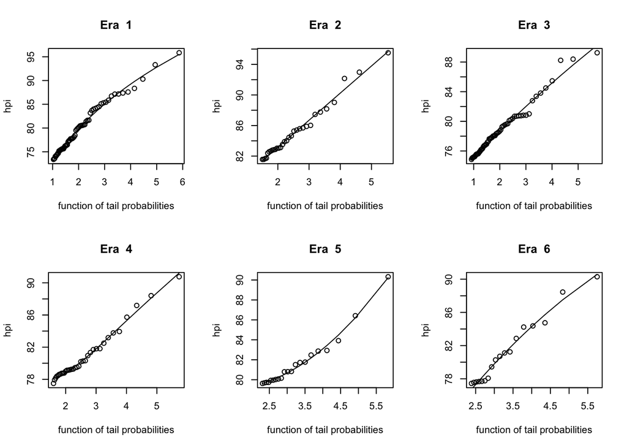

```r
par(mfrow = c(2,3))
for(j in 1:6){
  plot(out_M_8[[j]]$W, out_M_8[[j]]$Y, main = paste("Era ", j),
       xlab = "function of tail probabilities", ylab = "hpi")
  lines(out_M_8[[j]]$W, predict(out_M_8[[j]]$model))
}
```

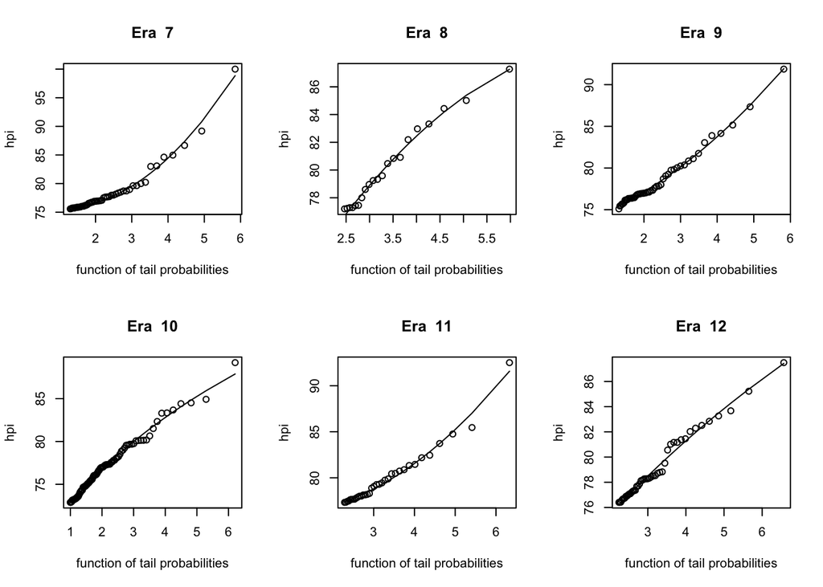

```r
par(mfrow = c(2,3))
for(j in 7:12){
  plot(out_M_8[[j]]$W, out_M_8[[j]]$Y, main = paste("Era ", j),
       xlab = "function of tail probabilities", ylab = "hpi")
  lines(out_M_8[[j]]$W, predict(out_M_8[[j]]$model))
}
```

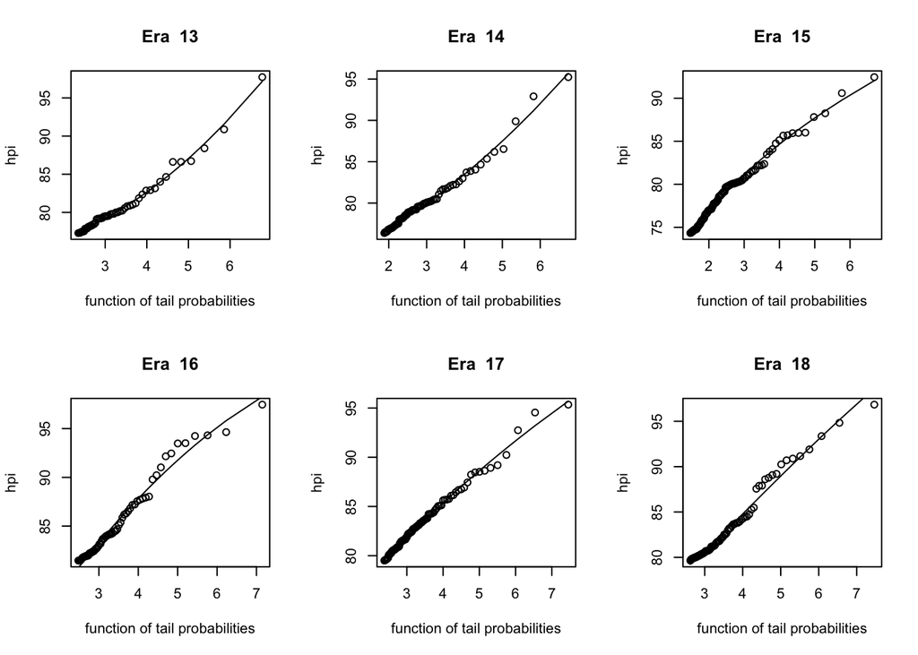

```r
par(mfrow = c(2,3))
for(j in 13:18){
  plot(out_M_8[[j]]$W, out_M_8[[j]]$Y, main = paste("Era ", j),
       xlab = "function of tail probabilities", ylab = "hpi")
  lines(out_M_8[[j]]$W, predict(out_M_8[[j]]$model))
}
```

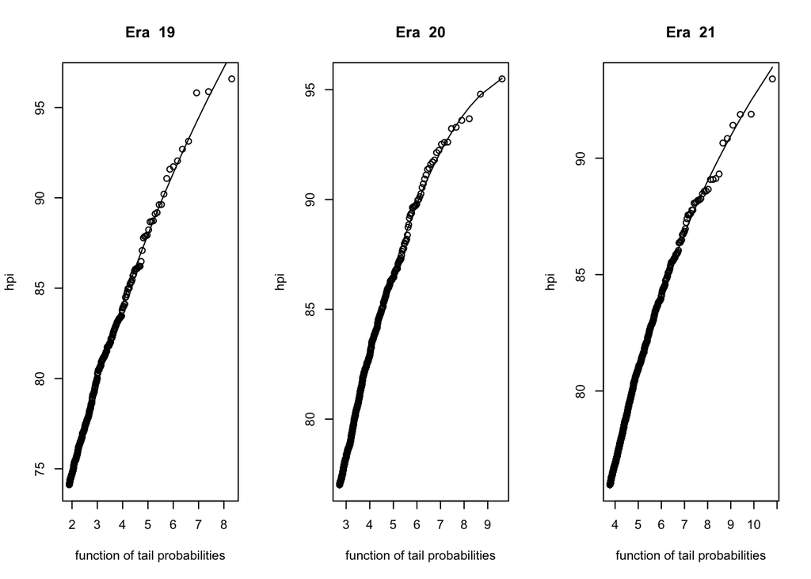

```r
par(mfrow = c(1,3))
for(j in 19:21){
  plot(out_M_8[[j]]$W, out_M_8[[j]]$Y, main = paste("Era ", j),
       xlab = "function of tail probabilities", ylab = "hpi")
  lines(out_M_8[[j]]$W, predict(out_M_8[[j]]$model))
}
```

We now compute latent talent estimates using Full House Modeling using the function.

```r
## vs your peers
system.time({
  hpi_adjust_vs_peers_M_8 =
    mclapply(seq_along(hpi_generations_M_8), mc.cores = nCores, function(j){
      talent_computing_nonpara(ystar = as.numeric(ystar_mat_M_8[j, 1]),
                               y = hpi_generations_M_8[[j]]$hpi,
                               npop = Epop_generations_8[[j]])
      })
  })
```

```
##    user  system elapsed
##  51.195   0.695 548.187
```

```r
hpi_era_adjusted_M_8 = do.call(rbind, lapply(seq_along(hpi_adjust_vs_peers_M_8), function(j){
  foo = cbind(hpi_generations_M_8[[j]], hpi_adjust_vs_peers_M_8[j])
  colnames(foo)[ncol(foo)] = "talent"
  foo
})) %>% select(-gender) %>%
  arrange(desc(talent))
```

Here is the top 50 list of the most impactful males in history ranked by estimated latent talent obtained via Full House Modeling. In this analysis there are 21 distinct eras defined by centuries to designate peer groups.

```r
hpi_era_adjusted_M_8 %>% as.data.frame() %>% head(50)
```

```
##                       name birthyear bplace_country       hpi   talent
## 1             Adolf Hitler      1889        Austria  95.48942 6.014225
## 2       Johannes Gutenberg      1394        Germany  92.44853 5.952893
## 3              Che Guevara      1928      Argentina  93.40716 5.947786
## 4           Ragnar Lodbrok       850 United Kingdom  89.20628 5.942747
## 5          Galileo Galilei      1564          Italy  95.34711 5.940984
## 6     Ludwig van Beethoven      1770        Germany  96.58397 5.940299
## 7             Isaac Newton      1643 United Kingdom  96.83657 5.920824
## 8          Albert Einstein      1879        Germany  94.79355 5.901589
## 9             Genghis Khan      1162       Mongolia  97.72367 5.900139
## 10              Marco Polo      1254          Italy  95.22918 5.890416
## 11       Leonardo da Vinci      1452          Italy  97.46069 5.889925
## 12                Avicenna       980     Uzbekistan  92.50853 5.877833
## 13            Omar Khayyam      1048           Iran  87.49654 5.872471
## 14     William Shakespeare      1564 United Kingdom  94.54765 5.851609
```

[output cut: 36 more lines]

Back to topics

## Combined Analysis

We now combine the results from the separate analyses. Several of the most impactful historical figures are females. This is in stark contrast to previous analyses performed on data with baked-in gender biases.

```r
hpi_adjust_vs_peers =
  rbind(hpi_era_adjusted_M_8,
        hpi_era_adjusted_F_8) %>%
  arrange(desc(talent))
hpi_adjust_vs_peers[1:50, ]
```

```
##                          name birthyear bplace_country       hpi   talent
## 1                Elizabeth II      1926 United Kingdom  93.04777 6.031743
## 2                Adolf Hitler      1889        Austria  95.48942 6.014225
## 3                 Marie Curie      1867         Poland  90.85337 6.007910
## 4          Mary II of England      1662 United Kingdom  85.89593 5.987234
## 5                 Joan of Arc      1412         France  92.46169 5.975767
## 6          Johannes Gutenberg      1394        Germany  92.44853 5.952893
## 7            Marie Antoinette      1755        Austria  88.67393 5.952432
## 8                 Che Guevara      1928      Argentina  93.40716 5.947786
## 9              Ragnar Lodbrok       850 United Kingdom  89.20628 5.942747
## 10            Galileo Galilei      1564          Italy  95.34711 5.940984
## 11       Ludwig van Beethoven      1770        Germany  96.58397 5.940299
## 12     Elizabeth I of England      1533 United Kingdom  90.90742 5.922610
## 13               Isaac Newton      1643 United Kingdom  96.83657 5.920824
## 14            Albert Einstein      1879        Germany  94.79355 5.901589
```

[output cut: 36 more lines]

Back to topics